# CV SKILL EXTRACTION

##### Questo notebook riporta un'esempio di implementazione di un sistema per l'estrazione delle informazioni relative alle skills contenute nei CV tramite NLP, e la rappresentazione in forma di grafo delle skills in base alla loro affinità semantica. A tal fine si è pensato di costruire un modello allenato su un piccolo dataset costruito manualmete e testato su un CV di esempio. Il risultato finale consiste nella definizione della funzione "extract_skills" la quale prende come argomento una stringa e fornisce in output tutte le skills che il modello è stato in grado di estrarre.

##### Il codice python riportato necessità dei seguenti pacchetti e risulta inoltre riutilizzabile in ambiente R tramite il pacchetto reticulate

```python
#vec2graph==0.3.0
#tensorflow==2.1.0
#pandas==1.0.1
#matplotlib==3.1.3
#gensim==3.8.3
#nltk==3.5
#numpy==1.18.1
#spacy==2.3.2
#fitz==0.0.1.dev2
#scikit_learn==0.23.2
#spacy en_core_web_sm
#nltk==3.5
```

### TRAINING DATASET

##### Il Punto di partenza e anche quello più fondamentale è la disponibilità di un dataset fatto su misura sul quale allenare il modello, in questo esempio si è deciso di crearne uno utilizzando 4 curriculum generici in formato .pdf trovati sul web. L'approccio alla risoluzione del problema è quello di unire il contenuto dei diversi file ottenendo un unico testo, dividere il testo unico in frasi nominali e costruire un dataset dove ad ogni pezzo di testo viene assegnata la categoria skill/non skill. Il problema si riduce a questo punto a quello di una classificazione binaria.

```python
import pandas as pd
import numpy as np
import spacy
import fitz
```

```python
fnames = ['./cvs/Academic Advisor.pdf',
          './cvs/Academic Librarian.pdf',
          './cvs/Fresher Graduate.pdf',
          './cvs/Graduate Nurse Practitioner.pdf'] # lista contenente i nomi dei file per il traning dataset
```

```python
text = ""
for i in range(len(fnames)):
    doc = fitz.open(fnames[i])
    for page in doc:
        text = text + str(page.getText())#concateno tutte le pagine di tutti i pdf

text = '  '.join(text.split('\n'))#elimino tutti i caratteri new line e semplifico la formattazione
#text
```

##### Una volta ottenuto il testo unificato di tutti i file pdf si procede prima con la pulizia del testo da ogni eventuale punteggiatura o simbolo non desiderato fra parole separate, in seguito si divide il testo in frasi nominali. Per questo task si è deciso di utilizzare il modello pre allenato "en_core_web_md" della libreria spacy.

```python
nlp = spacy.load("en_core_web_md")
punteggiatura='!"#$%&\'()*,//:;<=>?@[\\]^_`{|}~'
doc_nlp = nlp(text)
sk=[]
for chunk in doc_nlp.noun_chunks:
    #print(chunk.text)
    text_chunk=chunk.text
    sk.append(text_chunk.strip(punteggiatura))
sk=list(set(sk))
df=pd.DataFrame(sk,columns=['Chuncks'])
df.head()
```

|  | Chuncks |
| --- | --- |
| 0 |  |
| 1 | a great idea |
| 2 | the keywords |
| 3 | Practice Nursing Experience |
| 4 | Memberships |

##### Si è proceduto con il labeling manuale skill/non-skill di ogni pezzo di testo contenuto nel dataframe appena costruito ottenendo il seguente risultato:

```python
df=pd.read_csv('./Train_db.csv')
print('Conto skills vs non skills:\n',df['skill'].value_counts(),'\n\n')
df.tail(10)
```

```
Conto skills vs non skills:
 0    769
1    259
Name: skill, dtype: int64
```

|  | chunck | skill |
| --- | --- | --- |
| 1018 | any order | 0 |
| 1019 | javascript | 1 |
| 1020 | your previous education | 0 |
| 1021 | the latest tools | 0 |
| 1022 | structure xxth | 0 |
| 1023 | skill | 0 |
| 1024 | personal information | 0 |
| 1025 | c++ | 1 |
| 1026 | java | 1 |
| 1027 | statisticalprocess analysis | 1 |

##### Come si può notare il dataset costruito risulta sbilanciato con 769 valori non-skill codificati come valore '0' ed 259 valori skill codificati come valore '1'. Si procede quindi col calcolo dei pesi di penalizzazione che verrano passati al modello in fase di training per tenere in conto lo sbilanciamento:

```python
from sklearn.utils import class_weight
class_weights = class_weight.compute_class_weight('balanced',np.unique(df['skill']),df['skill'])
class_weights = dict(enumerate(class_weights))
class_weights
```

```
{0: 0.6684005201560468, 1: 1.9845559845559846}
```

### MODELLO NLP

##### Per quanto risguarda l'architettura del modello si è deciso di implementare una architettura a rete neurale ricorrente ed in particolare il modello Long Short Term Memory (LSTM) in configurazione standard e bidirezionale per mantenere quanto più possibile l'informazione relativa al contesto dei diversi termini. Il modello prevede anche l'inserimento di un embedding layer a monte del LSTM al fine di ottenere un vocabolario il quale contiene la rappresentazione vettoriale di ogni parola dalla quale si sarà poi in grado di risalire all'informazione relativa al contesto semantico.

##### Risultano ora necessari i seguenti import

```python
import tensorflow as tf
from tensorflow.keras.preprocessing.text import Tokenizer
from tensorflow.keras.preprocessing.sequence import pad_sequences
import matplotlib.pyplot as plt
from sklearn.preprocessing import LabelEncoder
import pickle
from nltk.corpus import stopwords
```

##### La seguente funzione serve per l'eliminazione delle delle stop words:

```python
def filter_stop_words(train_sentences):
    stop_words = set(stopwords.words("english"))
    for i, sentence in enumerate(train_sentences):
        new_sent = [word for word in sentence.split() if word not in stop_words]
        train_sentences[i] = ' '.join(new_sent)

    return train_sentences
```

##### La seguente funzione ha l'obiettivo di creare un dizionario numerico con le parole della colonna contenente il testo, sotituire le parole di ogni casella con il suo valore ed effettuare il padding al fine di avere la colonna dei pezzi di testo di lunghezza omogenea

```python
def token_and_sequence(text_col,padding_pre_or_post,return_df=False,max_num_words=None,max_len_padded=None):

    if max_num_words:
        tokenizer = Tokenizer(num_words=max_num_words,oov_token='out_of_vocab',filters=punteggiatura)
    else:
        tokenizer = Tokenizer(oov_token='out_of_vocab')

    text_col=filter_stop_words(text_col)
    tokenizer.fit_on_texts(text_col)
    dictionary=tokenizer.index_word
    #print(len(dictionary))
    encode_text=tokenizer.texts_to_sequences(text_col)

    if max_len_padded:
        pad_= pad_sequences(sequences=encode_text,padding=padding_pre_or_post,maxlen=max_len_padded)
    else:
        pad_ = pad_sequences(sequences=encode_text, padding=padding_pre_or_post)


    #non_zeros = np.count_nonzero(pad_, axis=0)
    #plt.bar(np.arange(len(non_zeros)), non_zeros)
    #plt.show()

    with open('tokenizer.pickle', 'wb') as handle:
        pickle.dump(tokenizer, handle, protocol=pickle.HIGHEST_PROTOCOL)

    if return_df==True:
        names = [('text_' + str(x)) for x in range(pad_.shape[1])]
        encod_df = pd.DataFrame(pad_.tolist(), columns=names)
        return encod_df,tokenizer,dictionary

    return pad_,tokenizer,dictionary
```

##### Si è deciso di utilizzare un embedding layer di 1085x35 con 1084 pari al numero delle parole complessive nel dataset di allenamento, e 35 valore arbitrario che rappresenterà la dimensione del vettore associato ad ogni parola del vocabolario. Il modello prevede a cascata un convolution layer con 5 filtri,dimensione kernel pari a 3 e attivazione relu, un fully connected layer a 128 nodi e attivazione relu, un LSTM bidirezionale a 64 nodi seguito da un LSTM a 32 nodi, ed infine il nodo di output con attivazione sigmoidea.

##### Al Termine dell'allenamento risultano i seguenti grafici delle curve di apprendimento e validazione

```python
X = df['chunck']
Y = df['skill']
vocab_size = 1085
len_sentence = 10
len_embedding=35
X, tokenizer_, word_index = token_and_sequence(X, 'post', max_num_words=vocab_size, max_len_padded=len_sentence)


model = tf.keras.Sequential([
    tf.keras.layers.Embedding(vocab_size, len_embedding, input_length=X.shape[1]),
    tf.keras.layers.Conv1D(5,3,activation='relu'),
    #tf.keras.layers.GlobalMaxPooling1D(),
    tf.keras.layers.Dense(128, activation='relu'),
    tf.keras.layers.Bidirectional(tf.keras.layers.LSTM(64, return_sequences=True)),
    tf.keras.layers.LSTM(32),
    tf.keras.layers.Dense(1, activation='sigmoid')])
print(model.summary())

opt = tf.keras.optimizers.Adam(learning_rate=0.01)
model.compile(optimizer=opt, loss='binary_crossentropy', metrics=['acc'])
history = model.fit(X, Y, batch_size=256, epochs=150,validation_split=0.25,shuffle=True,class_weight=class_weights)

y_acc = history.history['acc']
y_val = history.history['val_acc']
y_val_loss=history.history['val_loss']
y_loss=history.history['loss']


model.save('resumes_model')
```

```
Model: "sequential_11"
_________________________________________________________________
Layer (type)                 Output Shape              Param #
=================================================================
embedding_11 (Embedding)     (None, 10, 35)            37975
_________________________________________________________________
conv1d_11 (Conv1D)           (None, 8, 5)              530
_________________________________________________________________
dense_22 (Dense)             (None, 8, 128)            768
_________________________________________________________________
bidirectional_11 (Bidirectio (None, 8, 128)            98816
_________________________________________________________________
lstm_23 (LSTM)               (None, 32)                20608
_________________________________________________________________
dense_23 (Dense)             (None, 1)                 33
=================================================================
Total params: 158,730
Trainable params: 158,730
Non-trainable params: 0
_________________________________________________________________
None
WARNING:tensorflow:sample_weight modes were coerced from
  ...
    to
  ['...']
WARNING:tensorflow:sample_weight modes were coerced from
  ...
    to
  ['...']
Train on 771 samples, validate on 257 samples
```

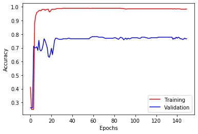

```python
plt.plot(y_acc, 'r',label="Training")
plt.plot(y_val, 'b',label='Validation')
plt.legend(loc="lower right")
plt.xlabel('Epochs')
plt.ylabel('Accuracy')
plt.show()
```

##### Come si può notare dalle curve il modello tende ad andare in overfitting in maniera molto veloce e questo fatto è legato principalmente alla scarsa quantità di dati utilizzati per l'allenamento, aumentando il dataset il problema dovrebbe ridursi, l'accuratezza sui dati di validazione fino a questo punto si attesta attorno al 77%.

##### Una volta allenato e salvato il modello si può procedere con la definizione di una funzione "extract_skills" finalizzata all'estrazione delle skills dal generico testo: la funzione prende come argomento la stringa contenente il testo, e la soglia di certezza con il quale il modello deve predire le skills, e fornisce in output la lista delle skills con i relativi valori di certezza. Quanto più il valore di certezza si avvicina ad 1 tanto più il modello è sicuro di aver predetto una skill, viceversa per valori vicini a zero.

```python
import tensorflow as tf
import re
import fitz
import spacy
from tensorflow.keras.preprocessing.sequence import pad_sequences
import pickle
from nltk.corpus import stopwords


def get_text(filename):
    text = ""
    for i in range(len(filename)):
        doc = fitz.open(filename[i])
        for page in doc:
            text = text + str(page.getText())
    text = ' '.join(text.split('\n'))
    return text


def extract_skills(text,threshold_certezza):

    #Carico modello e dizionario dei termini
    model = tf.keras.models.load_model('resumes_model')
    with open('tokenizer.pickle', 'rb') as handle:
        tokenizer_ = pickle.load(handle)

    nlp = spacy.load("en_core_web_sm")
    doc_nlp = nlp(text)
    txt_chunks = []
    for chunk in doc_nlp.noun_chunks:
        text_chunk= chunk.text.strip(punteggiatura).lower()
        txt_chunks.append(text_chunk)
        #print(text_chunk)

    txt_chunks = list(set(txt_chunks))
    txt_chunks = filter_stop_words(txt_chunks)
    encode_test = tokenizer_.texts_to_sequences(txt_chunks)

    len_sentence = 10
    x = pad_sequences(sequences=encode_test, padding='post', maxlen=len_sentence)
    #print(x)
    y_pred = model.predict(x)

    l_skills=[]
    print('\n\nExtracted Skills list:\n\n')
    for i in range(len(y_pred)):
        if y_pred[i] >= threshold_certezza:
            l_skills.append([txt_chunks[i], y_pred[i].item()])

    return l_skills
```

##### Si procede a provare il modello sul seguente esempio di cv da programmatore reperito sul web:

```python
filename = ['./cvs/programmer.pdf']
text = get_text(filename)
text
```

```
'  Experienced and talented programmer who enjoys solving problems and is highly passionate about web application  development and software design. Focused and knowledgeable, with strong attention to details and ability to  concentrate. Excellent critical thinking and analytical skills, with track r…
```

##### Si prova il modello con un threshold pari a 0.9

```python
extracted_skills=extract_skills(text,0.9)
extracted_skills
```

```
Extracted Skills list:
```

```
[['software', 0.998180627822876],
 ['java', 0.9981828331947327],
 ['software designs', 0.9981787204742432],
 ['california skills', 0.9981809854507446],
 ['ability', 0.9981820583343506],
 ['c++', 0.9981829524040222],
 ['computer', 0.9981829524040222],
 ['python', 0.9981821775436401],
 ['strong attention', 0.9981828331947327],
 ['information technology', 0.9981607794761658],
 ['track record', 0.9981826543807983],
 ['client applications', 0.9963312745094299],
 ['project requirements', 0.9906179308891296],
 ['education', 0.9981777667999268],
 ['analytical skills', 0.9981809854507446],
 ['higher level systems', 0.9981630444526672],
 ['excellent critical thinking', 0.9981829524040222],
 ['programmed web-based applications', 0.9981776475906372],
 ['excellent critical thinking', 0.9981829524040222],
 ['ability', 0.9981820583343506],
 ['web applications', 0.9963312745094299]]
```

##### Come si può notare nonostante si utilizzi un modello molto semplice si riesce ad estrarre un buon numero di skills nonostante il risultato sia affetto da disturbo. Risulta ovvio che il risultato è fortemente legato a come sono state definite le skills nel dataset di allenamento, ai termini del dizionario a cui il modello fa riferimento, e a come è stato processato il testo estratto dai file pdf.

### ANALISI SEMANTICA

##### Per quanto riguarda l'analisi semantica, l' embedding layer del modello contiene 1085 parole codificate come vettori di dimensione 35. Si può visualizzare la rappresentazione spaziale dei termini tramite il PCA e l'embedding projector di Tensorflow in questo caso permette di semplificare l'operazione: basta infatti salvare il dizionario in due file metadata.tsv e vettori.tsv e utilizzare l'embedding projector al sito https://projector.tensorflow.org per visualizzare il risultato.

```python
import io

embedding_layer = model.layers[0]
embedding_weights = embedding_layer.get_weights()[0]
print("numero termini del vocabolario: ",embedding_weights.shape[0],'\nDimensione vettori: ',embedding_weights.shape[1])
out_v = io.open('vecs_res.tsv', 'w', encoding='utf-8')
out_m = io.open('meta_res.tsv', 'w', encoding='utf-8')
for word_n in range(1, vocab_size):
    w = word_index[word_n]
    emb = embedding_weights[word_n]
    out_m.write(w + '\n')
    out_v.write('\t'.join([str(x) for x in emb]) + '\n')
out_v.close()
out_m.close()
```

```
numero termini del vocabolario:  1085
Dimensione vettori:  35
```

##### Caricando i due file .tsv sul projector risulta la eguente rappresentazione:

[figure not shown]

##### Come si può vedere poichè si è allenato il modello a classificare le frasi nominali fra skill e non skill, i termini del dizionario tendono a formare 2 cluster accumunati da valore semantico.

##### Dato un termine (es. 'c++') risulta possibile anche visualizzare anche quelli che sono più affini tramite il valore del coseno di similitudine:

[figure not shown]

##### La rappresentazione riportata sopra fa tuttavia riferimento a tutti i termini del dizionario costruito sulla base di tutti i termini contenuti nel dataset di training. Per l'analisi semantica delle sole skills risulta necessario quindi estrarre quest'ultime dal dizionario completo. Nel nostro caso si possono però estrarre solo i termini presi singolarmente dalle frasi nominali classificate come skills, in quanto il dizionario del modello è stato costruito su singoli termini tramite il tokenizer: questo se da un lato genera noise dovuto al fatto che vengono estratti anche i termini che non rappresentano direttamente delle skills, dall'altro permette di avere un' informazione più dettagliata del contesto nel quale il termine viene maggiormente utilizzato. Un'approccio alternativo può essere quello di creare un dizionario che incorpori anche le frasi nominali o assiemi di parole utili, che verrebbe codificato nell'embedding. L'utima opzione tuttavia potrebbe porre problemi di ridondanza e di riconoscimento delle skill in testi nuovi, visto che le frasi indicanti skills dovrebbero avere l'esatta formattazione di quelle contenute nel dizionario del modello.

```python
skills_list=df[df['skill']==1]
#skills_list.head(20)
skills_list=pd.Series(skills_list['chunck'].str.lower().values.tolist())
skills_list = filter_stop_words(skills_list)
skills_list=skills_list.str.cat(sep=' ')
skills_list=skills_list.split()
skills_words=list(set(skills_list))
print(sorted(skills_words))
```

```
['2', '2013', '3340', '387', 'ability', 'academic', 'accomplishments', 'achievements', 'additional', 'advanced', 'advising', 'advisor', 'aerodynamic', 'aerosol', 'aerosolnanoparticle', 'aerospace', 'agglomerated', 'aggregates', 'air', 'airborne', 'analysis', 'analyzer', 'angle', 'anical', 'anne', 'a…
```

##### Una volta ottenuta la lista dei termini di categoria skill si può procedere all'estrazione dei corrispettivi vettori dal dizionario, per fare ciò risulta necessario invertire il dizionario ed ottenere la chiave della parola da passare alla lista contentente i vettori di tutti i termini

```python
reverse_word_index=dict([(value,key) for (key,value) in word_index.items()])
```

```python
w2v = io.open('emb_res_.txt', 'w')
w2v.write(str(len(skills_list) - 1) + ' '+str(len_embedding)+'\n')
for word_n in skills_list:
    w = reverse_word_index[word_n.lower()]
    emb = embedding_weights[w-1]
    w2v.write(word_n + ' ' + ' '.join([str(x) for x in emb]) + '\n')
w2v.close()
```

##### Per la rappresentazione delle relazioni in forma di grafo si usa la libreria vec2graph. Data un ternime o una lista di termini la funzione "visualize" crea un force-directed graph che riporta un numero arbitrario di termini caratterizzati da maggiore similarità sulla base del coseno di similitudine; si può quindi anche assegnare un valore soglia affinche vengano collegati solo nodi fra i quali il coseno di similitudine assume valori uguali o maggiori rispetto a quello soglia. Si riporta di seguito il grafo d'esempio per la parola engineering:

```python
from gensim import models
from vec2graph import visualize

model_graph = models.KeyedVectors.load_word2vec_format('emb_res_.txt', binary=False, unicode_errors='replace')

visualize('tmp/graphs', model_graph, words=['engineering'],topn=5,threshold=0.77)
```

```
Visualizations written to tmp/graphs
```

```
['engineering']
```

[figure not shown]